# Confidence Intervals for a Single Mean

Download R Markdown source (.Rmd)

Standard errors, critical values, and the z and t intervals.

A hospital quality team wants to estimate the average wait time for patients. A random sample gives a sample mean, but the team knows that another sample would give a different mean. The confidence interval for a single mean puts a margin of error around that sample mean.

This reading covers the one-sample confidence interval for a population mean \(\mu\). The main decision is whether the population standard deviation \(\sigma\) is known or unknown. That decision determines whether we use a \(z\) interval or a \(t\) interval.

## The estimate and its standard error

The population mean is \(\mu\). The sample mean is

$$ \bar x=\frac{1}{n}\sum_{i=1}^n x_i. $$

The sample mean is the point estimate of \(\mu\). Its sampling distribution is centered at \(\mu\), and its standard error is

$$ SE(\bar x)=\frac{\sigma}{\sqrt n} $$

when the population standard deviation \(\sigma\) is known. When \(\sigma\) is unknown, we estimate it with the sample standard deviation \(s\), giving the estimated standard error

$$ \widehat{SE}(\bar x)=\frac{s}{\sqrt n}. $$

The standard error measures the typical distance between a sample mean and the population mean over repeated samples. A larger sample gives a smaller standard error.

## The interval when \(\sigma\) is known

When the population standard deviation is known, the **one-sample \(z\) interval** starts with the standardized statistic

$$ Z=\frac{\bar X-\mu}{\sigma/\sqrt n}. $$

If the sampling distribution of \(\bar X\) is approximately normal, then \(Z\) has a standard normal distribution. For a confidence level \(c=1-\alpha\), the critical value \(z^*\) is the \(1-\alpha/2\) quantile of the standard normal distribution. It satisfies

$$ P(-z^*<Z<z^*)=c. $$

The figure shows the central probability \(c\) and the two tail probabilities \((1-c)/2\).

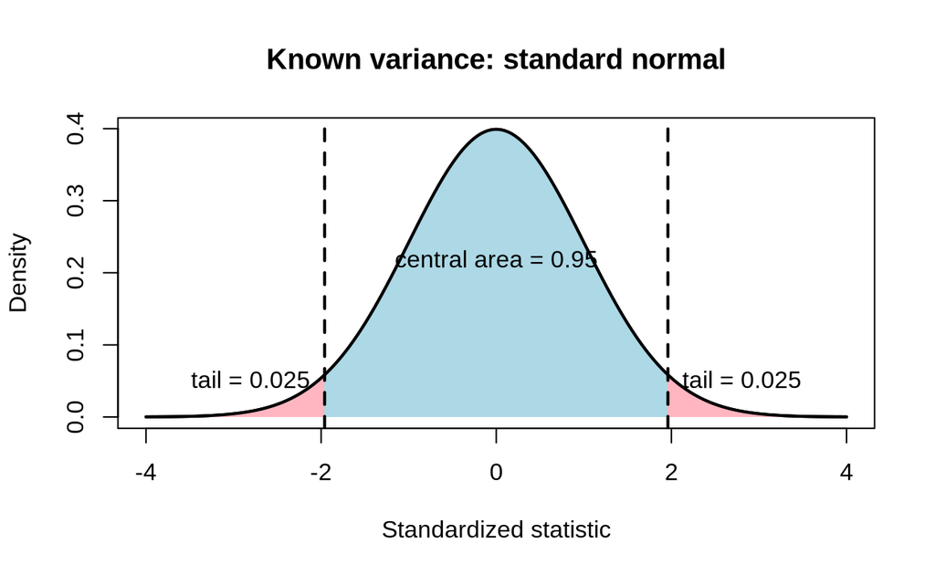

Standard normal distribution with a 95% central region and 2.5% in each tail.

Using the general recipe from the first reading with this standardized statistic gives

$$ \bar x \pm z^*\frac{\sigma}{\sqrt n}. $$

The value \(\alpha\) is the noncoverage probability. For a 95% interval, \(\alpha=0.05\), and \(z^*\) is the value that leaves \(0.025\) in each tail.

Common critical values are:

| Confidence level | \(z^*\) |
| --- | --- |
| 90% | 1.645 |
| 95% | 1.960 |
| 99% | 2.576 |

The margin of error is

$$ ME=z^*\frac{\sigma}{\sqrt n}, $$

and the interval can be written as \((\bar x-ME,\ \bar x+ME)\). The width is \(2ME\).

This procedure requires a normal model for the sampling distribution of \(\bar x\). If the population is approximately normal, the sampling distribution is approximately normal for any sample size. If the population is not normal, we rely on the central limit theorem and the course guideline that \(n>30\) is large enough for a clearly nonnormal population.

## The interval when \(\sigma\) is unknown

In most real problems, the population standard deviation is unknown. We then estimate \(\sigma\) with the sample standard deviation \(s\). The extra uncertainty from estimating \(\sigma\) is handled by using **Student’s \(t\) distribution** instead of a standard normal distribution.

The standardized statistic is

$$ T=\frac{\bar X-\mu}{S/\sqrt n}. $$

When the sampling distribution of \(\bar X\) is approximately normal, \(T\) has a \(t\) distribution with

$$ df=n-1 $$

**degrees of freedom**. For a confidence level \(c=1-\alpha\), the critical value \(t^*\) is the \(1-\alpha/2\) quantile of that \(t\) distribution. It satisfies

$$ P(-t^*<T<t^*)=c. $$

The figure shows the central probability and the two tail probabilities for a \(t\) distribution with \(df=15\).

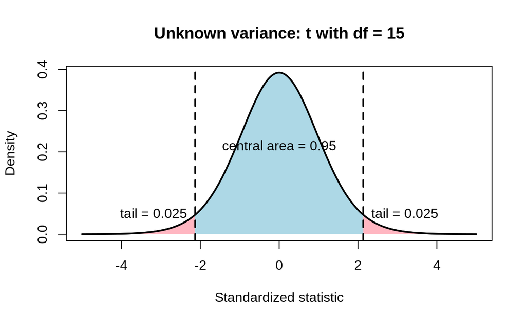

A t distribution with 15 degrees of freedom, a 95% central region, and 2.5% in each tail.

Using the general recipe from the first reading with this standardized statistic gives the **one-sample \(t\) interval**

$$ \bar x \pm t^*\frac{s}{\sqrt n}. $$

The margin of error is

$$ ME=t^*\frac{s}{\sqrt n}. $$

The \(t\) critical value is larger than the corresponding \(z\) critical value, especially for small samples. That makes the \(t\) interval wider. As the sample size grows, the \(t\) distribution becomes closer to the standard normal distribution, so \(t^*\) approaches \(z^*\).

Some common \(t\) critical values are:

| Confidence level | \(df=9\) | \(df=15\) | \(df=30\) |
| --- | --- | --- | --- |
| 90% | 1.833 | 1.753 | 1.697 |
| 95% | 2.262 | 2.131 | 2.042 |
| 99% | 3.250 | 2.947 | 2.750 |

The exact critical value depends on the degrees of freedom. In practice, use software or a \(t\) table.

## Conditions for a one-sample interval

For the one-sample \(z\) or \(t\) interval to be valid, the following conditions should be reasonable.

1. **Random or representative sample.** The data should come from a random sample or a sampling design that is representative of the population.
2. **Independence.** The observations should be independent, or nearly enough that the usual standard error formula is reasonable.
3. **Normal sampling distribution.** If the population is approximately normal, the sampling distribution of \(\bar x\) is approximately normal for any sample size. If the population is clearly nonnormal, the sample should be large enough for the central limit theorem. In this course, we use the guideline \(n>30\) for clearly nonnormal populations.
4. **Correct variance information.** Use a \(z\) interval when the population standard deviation is known. Use a \(t\) interval when it is unknown and estimated by \(s\).

If the sample is small and the population is strongly skewed, the interval may not be valid. A confidence interval can always be computed numerically, but it should not be interpreted as a reliable interval for \(\mu\) unless the conditions support the normal model.

## Worked example: a \(z\) interval

A researcher studies the mean daily sales at a bakery. A random sample of \(n=36\) days has sample mean \(\bar x=120.4\) dollars. Historical records indicate that the population standard deviation is \(\sigma=15.0\) dollars, and daily sales are approximately normally distributed.

For a 95% interval, \(z^*=1.96\). The standard error is

$$ \frac{15.0}{\sqrt{36}}=\frac{15}{6}=2.5, $$

and the margin of error is

$$ 1.96(2.5)=4.9. $$

The interval is

$$ (120.4-4.9,\ 120.4+4.9)=(115.5,\ 125.3). $$

We are 95% confident that the population mean daily sales is between 115.5 and 125.3 dollars.

```r
# Summary statistics for the bakery example.
xbar <- 120.4          # sample mean daily sales
sigma <- 15.0         # known population standard deviation
n <- 36               # sample size
z_star <- qnorm(0.975)  # 95% standard normal critical value

# Compute the standard error and margin of error.
se <- sigma / sqrt(n)  # standard error of the sample mean
me <- z_star * se      # margin of error

# Display the interval.
c(lower = xbar - me, upper = xbar + me)  # lower and upper endpoints
   lower    upper
115.5001 125.2999
```

## Worked example: a \(t\) interval

A random sample of \(n=16\) ceramic tiles has sample mean thickness \(\bar x=48.6\) mm and sample standard deviation \(s=8.4\) mm. The population is approximately normal, and the population standard deviation is unknown.

For a 95% interval with \(df=15\), \(t^*=2.131\). The standard error is

$$ \frac{8.4}{\sqrt{16}}=\frac{8.4}{4}=2.1, $$

and the margin of error is

$$ 2.131(2.1)\approx 4.48. $$

The interval is approximately

$$ (48.6-4.48,\ 48.6+4.48)=(44.12,\ 53.08). $$

We are 95% confident that the population mean thickness is between 44.12 and 53.08 mm.

```r
# Summary statistics for the ceramic tile example.
xbar <- 48.6            # sample mean thickness
s <- 8.4                # sample standard deviation
n <- 16                 # sample size
t_star <- qt(0.975, df = n - 1)  # 95% t critical value with df = n - 1

# Compute the standard error and margin of error.
se <- s / sqrt(n)  # estimated standard error of the sample mean
me <- t_star * se  # margin of error

# Display the interval.
c(lower = xbar - me, upper = xbar + me)  # lower and upper endpoints
   lower    upper
44.12396 53.07604
```

The same calculation can be done directly from raw data with `t.test()`. The interval is stored in the `conf.int` component.

```r
# A small sample of measurements.
measurements <- c(45.2, 47.8, 49.1, 50.4, 46.7, 48.3, 51.0, 47.5,
                  49.8, 50.1, 46.9, 48.6, 49.4, 47.1, 50.7, 48.0)

# Construct the 95% t interval for the population mean from the raw data.
# The conf.int component stores the lower and upper endpoints.
t.test(measurements, conf.level = 0.95)$conf.int
[1] 47.66151 49.41349
attr(,"conf.level")
[1] 0.95
```

## How width changes

For a fixed confidence level and population, the width of the interval depends on the standard error and the critical value.

- Increasing the sample size decreases the standard error, so the interval becomes narrower.
- Increasing the confidence level increases the critical value, so the interval becomes wider.
- More variability in the population produces a larger standard error and a wider interval.

For example, if the sample size is quadrupled, the standard error is halved. If the critical value stays approximately the same, the margin of error is approximately halved.

## Common mistakes

- **Using a \(z\) interval when \(\sigma\) is unknown.** If the population standard deviation is unknown, use a \(t\) interval with \(s\) and \(n-1\) degrees of freedom.
- **Using \(n\) instead of \(\sqrt n\) in the standard error.** The standard error is \(\sigma/\sqrt n\) or \(s/\sqrt n\).
- **Forgetting the degrees of freedom for a \(t\) interval.** For a one-sample \(t\) interval, \(df=n-1\).
- **Interpreting the interval as a statement about individual observations.** The interval estimates the population mean, not the range of individual values.
- **Calling the confidence level a probability for the parameter.** The confidence level describes the repeated-sampling procedure.
- **Ignoring the shape of the population when the sample is small.** A small sample from a strongly skewed population may not justify a \(t\) interval.

## Summary

For a single population mean:

- Use \(\bar x \pm z^*\sigma/\sqrt n\) when \(\sigma\) is known.
- Use \(\bar x \pm t^*s/\sqrt n\) with \(df=n-1\) when \(\sigma\) is unknown.
- Check that the sample is random and independent and that the sampling distribution of \(\bar x\) is approximately normal.
- Interpret the interval as a statement about the population mean \(\mu\), not about individual observations or the sample mean.

The next reading extends these ideas to the difference between two population means.